# M08 - Artrite Idiopática Juvenil (AIJ)

Pietro Garmatter

2024-09-17

```r
library(fpp3)
library(tidyverse)
library(RPostgres)
library(DBI)
library(GGally)
library(ggdist)
library(ggfortify)
library(MASS)
library(splines)
library(patchwork)
library(distributional)

setwd("E:/GEATS/Estimador-AIO-SUS/M08/")
load("M08.RData")

select <- dplyr::select
```

# Exploratória Soma

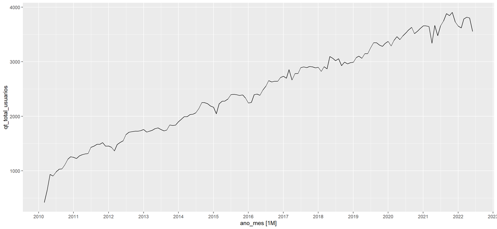

```r
autoplot(soma, qt_total_usuarios) +
  scale_x_yearmonth(date_breaks = '1 year', date_labels='%Y')
```

```r
mean(soma$qt_total_usuarios)
```

```
## [1] 2467.527
```

```r
var(soma$qt_total_usuarios)
```

```
## [1] 728189.4
```

Apesar de bastantes observações, média e variância diferentes. É possível fazer análises, mas não utilizar Poisson no GLM (superdispersão).

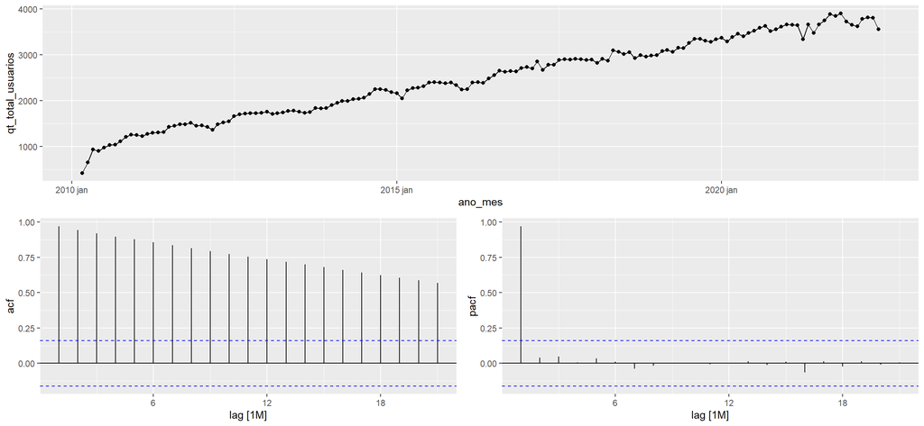

```r
gg_tsdisplay(soma, y = qt_total_usuarios, plot_type = "partial")
```

FAC e FACP sugerem processo AR(1). Série diferenciada bastante estacionária, certa variância maior perto do final.

```r
(lb12 = format(ljung_box(soma$qt_total_usuarios, lag = 12)["lb_pvalue"], nsmall = 4))
```

```
## lb_pvalue
##  "0.0000"
```

```r
(lb24 = format(ljung_box(soma$qt_total_usuarios, lag = 24)["lb_pvalue"], nsmall = 4))
```

```
## lb_pvalue
##  "0.0000"
```

Os testes de Ljung-Box para 12 e 24 meses rejeita a hipótese nula de que a série seja ruído branco com valores de p iguais a 0.0000 e 0.0000.

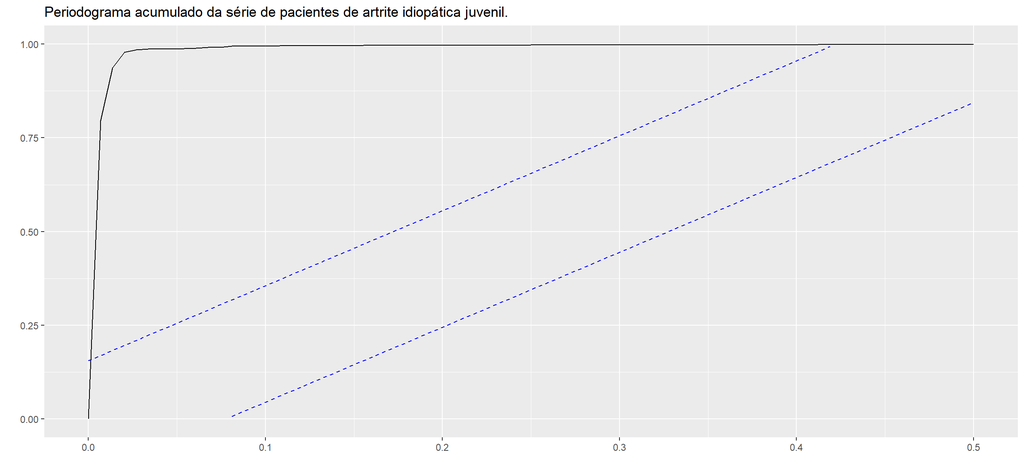

```r
ggcpgram(soma$qt_total_usuarios) +
  labs(title = 'Periodograma acumulado da série de pacientes de artrite idiopática juvenil.')
```

Tudo indica que a soma pode ser modelada.

# Modelagem Soma

Modelo proposto ARIMA(110) com drift e sem sazonalidade.

```r
soma.treino <- soma %>% filter(ano_mes < yearmonth("2020/06"))

models <- soma.treino %>%
  model(A = ARIMA(qt_total_usuarios ~ 1 + pdq(1,1,0) + PDQ(0,0,0)),
        B = ARIMA(qt_total_usuarios),
        C = ETS(qt_total_usuarios ~ error("A") + trend("A") + season("N")),
        D = ETS(qt_total_usuarios ~ error("M") + trend("A") + season("N")),
        E = TSLM(qt_total_usuarios ~ ano_mes))

quasipoisson = glm(qt_total_usuarios ~ ano_mes, soma.treino, family = quasipoisson())

binomialneg = glm.nb(qt_total_usuarios ~ ano_mes, soma.treino)
nb.label = "F"

glance(models) %>%
  select(.model, AIC) %>%
  bind_rows(data.frame(.model = c('quasipoisson', nb.label), AIC = c(NA, AIC(binomialneg))))
```

```
## # A tibble: 7 × 2
##   .model         AIC
##   <chr>        <dbl>
## 1 A            1380.
## 2 B            1377.
## 3 C            1643.
## 4 D            1686.
## 5 E            1136.
## 6 quasipoisson   NA
## 7 F            1705.
```

Modelo E (TSLM) teve o melhor AIC seguido de B (ARIMA(0,1,0)(1,0,0)[12] w/ drift encontrado com stepwise) e A (ARIMA proposto).

# Análise de resíduos (soma)

```r
newdata = soma %>% filter(ano_mes >= yearmonth("2020/06"))

cast <- models %>%
  forecast(new_data = newdata)

nb.cast = predict.glm(binomialneg, newdata, type="response")
nb.mean = nb.cast #uma por mes
nb.var = var(soma$qt_total_usuarios) #var da serie ou da série predita? NESSE CASO USEI DA SERIE POIS ESTAVA DANDO P>1

size = nb.mean^2 /(nb.var - nb.mean)
prob = nb.mean / nb.var

nb.cast = fable(.model = nb.label,
                ano_mes = unique(cast$ano_mes),
                qt_total_usuarios = dist_negative_binomial(size, prob),
                mean = nb.cast,
                d1 = c(NA, diff(nb.cast)),
                response = 'qt_total_usuarios',
                distribution = 'qt_total_usuarios')
```

```
## Using `ano_mes` as index variable.
```

```r
cast <- cast %>%
  bind_rows(nb.cast)

cast %>%
  accuracy(soma,
           list(REQM = RMSE,
                winkler = winkler_score), level = 95)
```

```
## # A tibble: 6 × 4
##   .model .type  REQM winkler
##   <chr>  <chr> <dbl>   <dbl>
## 1 A      Test   170.    831.
## 2 B      Test   172.    949.
## 3 C      Test   162.    779.
## 4 D      Test   161.   7325.
## 5 E      Test   149.   1128.
## 6 F      Test   763.   3334.
```

O modelo E teve um bom ajuste da média, com os menores resíduos registrados (REQM 148.5165), enquanto não teve um bom desempenho quanto ao intervalo preditivo (escore 1128.0271). No geral, o modelo C (suavização exponencial de Holt) teve um bom REQM (161.8803) e o melhor escore (778.8805).

# Análise dos gráficos Soma

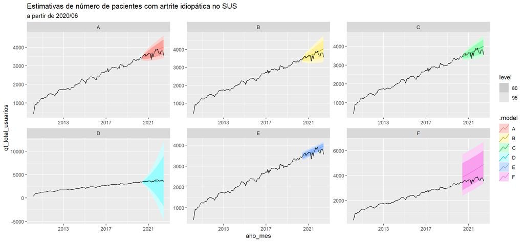

```r
cast %>%
  autoplot(soma) +
  facet_wrap(~ .model, scales = "free") +
  scale_x_yearmonth(date_breaks = '4 years', date_labels='%Y') +
  labs(title = "Estimativas de número de pacientes com artrite idiopática no SUS",
       subtitle = "a partir de 2020/06")
```

Tanto o modelo C quanto os ARIMAs (A e B) tiveram um comportamento utilizável na predição do número de pacientes totais de artrite idiopática juvenil no SUS. Preferencialmente, o modelo C.

# Análises de medicamentos

```r
tratamentos %>%
  select(no_identificador, via, linha_tto, periodicidade_poliarticular, periodicidade_sistemica) %>%
  unique()
```

```
##    no_identificador       via linha_tto periodicidade_poliarticular
## 1         ABAT60432 injetavel         4                          NA
## 3         ADAL60438 injetavel         4                           2
## 8         ETAN60438 injetavel         4                           1
## 11        INFL60438 injetavel         4                           8
## 13        LEFL60432      oral         2                           0
## 14        METO60453 injetavel         2                           1
## 15        METO60453      oral         2                           0
## 16        TOCI60469 injetavel         5                           4
##    periodicidade_sistemica
## 1                       NA
## 3                        2
## 8                        1
## 11                       8
## 13                       0
## 14                       1
## 15                       0
## 16                       2
```

Existem 8 tratamentos no total nos dados. Não foi possível encontrar informações de periodicidade na administração de abatacepte no protocolo (PCDT).

```r
meds <- meds %>%
  mutate(key = paste(no_identificador, via, sep = '_')) %>%
  as_tsibble(key = key, index = ano_mes)
```

Como a abordagem de modelagem da diferenciada da tendência não foi satisfatória para M45, o método não foi reproduzido para outros PCDTs. Segue-se para as outras análises.

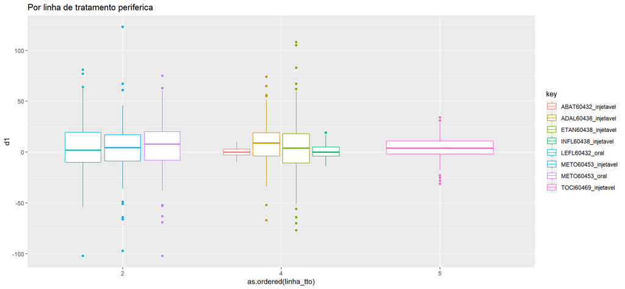

```r
# removendo diferenças maiores que +-200, pois são outliers e dificultam a visualização do restante.
meds <- meds %>% mutate(d1 = difference(qt_usuarios))

meds %>%
  filter(d1 > -200 & d1 < 200) %>%
  ggplot(aes(x = as.ordered(linha_tto), y = d1, colour = key)) +
  geom_boxplot() +
  labs(title = "Por linha de tratamento periferica")
```

Em média, a linha de tratamento não parece influenciar diretamente a taxa de difusão de cada tecnologia.

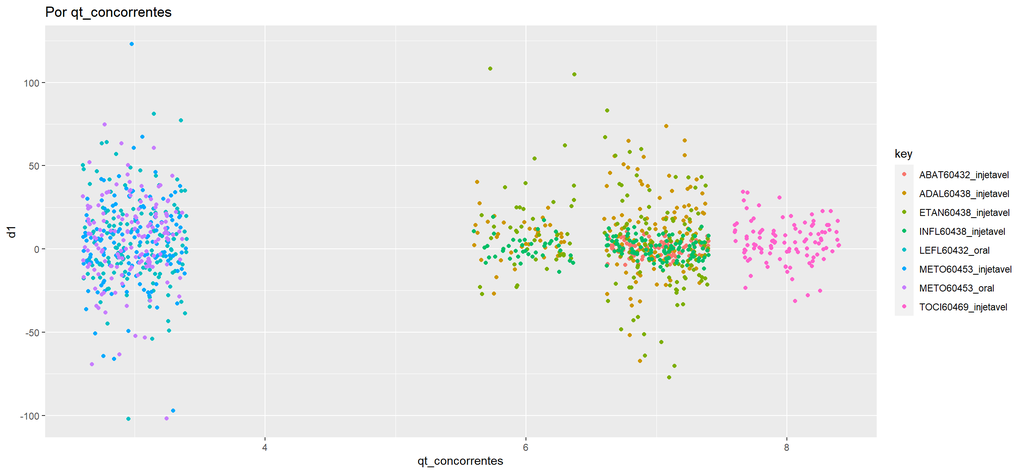

```r
meds %>%
  filter(d1 > -200 & d1 < 200) %>%
ggplot(aes(x = qt_concorrentes, y = d1, colour = key)) +
  geom_jitter() +
  labs(title = "Por qt_concorrentes")
```

O mesmo se observa para a quantidade de concorrentes, não parecendo ser um fator determinante na média da taxa de difusão, apesar de apresentar certa variância em diferentes estágios. Possível que seja explicado pelo tempo em que as tecnologias competem.

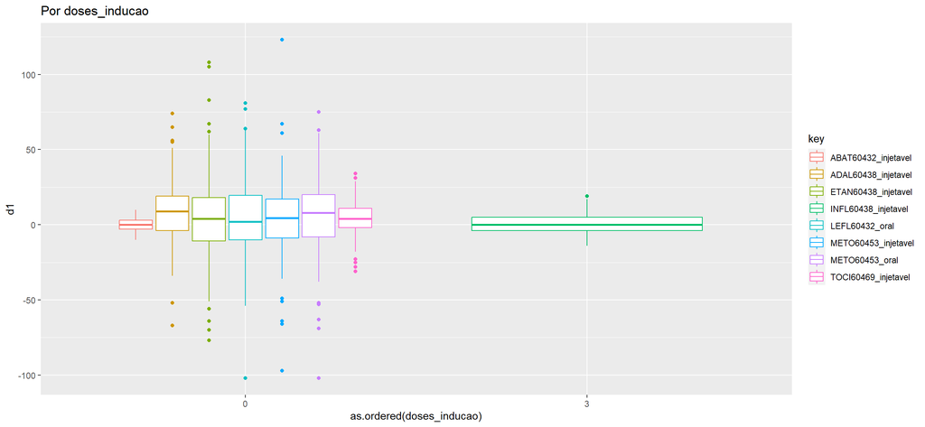

```r
meds %>%
  filter(d1 > -200 & d1 < 200) %>%
  ggplot(aes(x = as.ordered(doses_inducao), y = d1, colour = key)) +
  geom_boxplot() +
  labs(title = "Por doses_inducao")
```

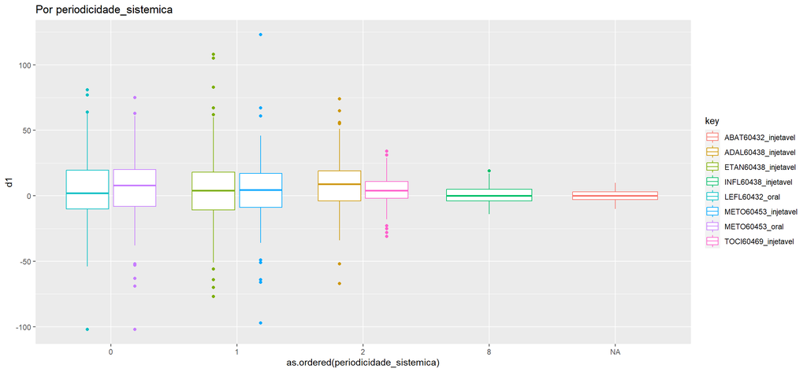

```r
meds %>%
  filter(d1 > -200 & d1 < 200) %>%
  ggplot(aes(x = as.ordered(periodicidade_sistemica), y = d1, colour = key)) +
  geom_boxplot() +
  labs(title = "Por periodicidade_sistemica")
```

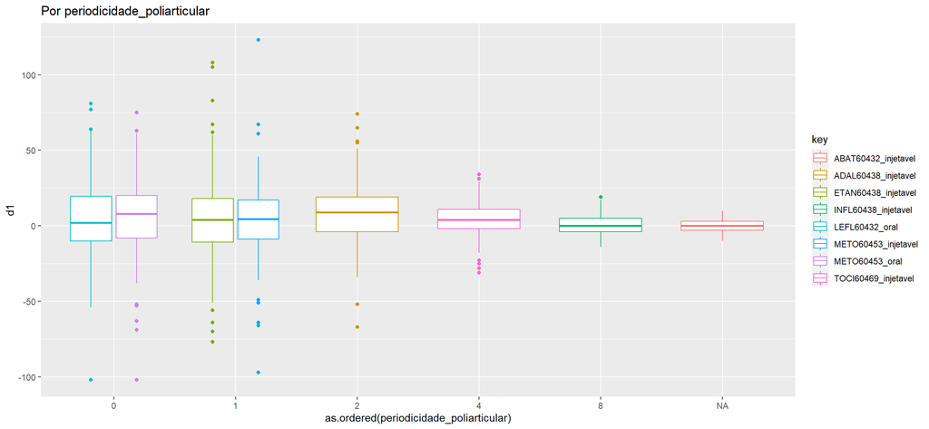

```r
meds %>%
  filter(d1 > -200 & d1 < 200) %>%
  ggplot(aes(x = as.ordered(periodicidade_poliarticular), y = d1, colour = key)) +
  geom_boxplot() +
  labs(title = "Por periodicidade_poliarticular")
```

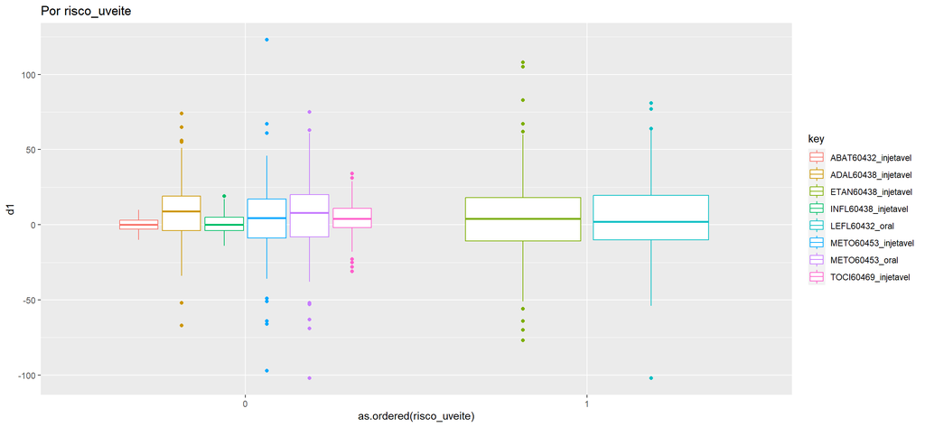

```r
meds %>%
  filter(d1 > -200 & d1 < 200) %>%
  ggplot(aes(x = as.ordered(risco_uveite), y = d1, colour = key)) +
  geom_boxplot() +
  labs(title = "Por risco_uveite")
```

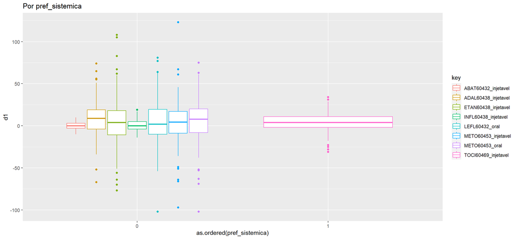

```r
meds %>%
  filter(d1 > -200 & d1 < 200) %>%
  ggplot(aes(x = as.ordered(pref_sistemica), y = d1, colour = key)) +
  geom_boxplot() +
  labs(title = "Por pref_sistemica")
```

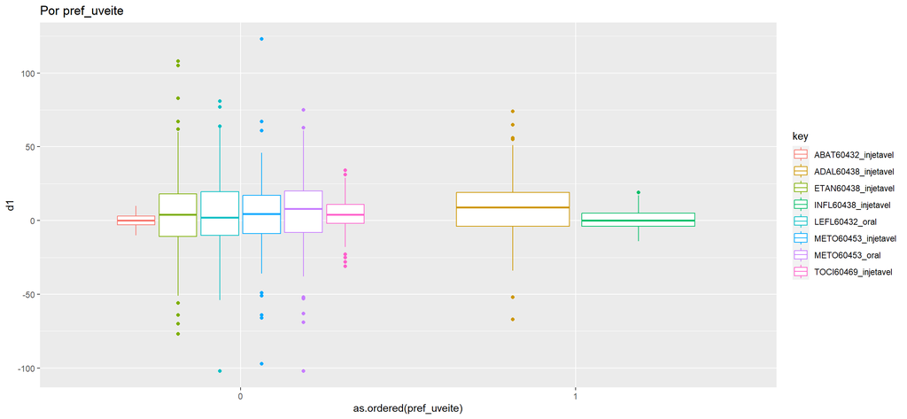

```r
meds %>%
  filter(d1 > -200 & d1 < 200) %>%
  ggplot(aes(x = as.ordered(pref_uveite), y = d1, colour = key)) +
  geom_boxplot() +
  labs(title = "Por pref_uveite")
```

Nenhuma das características definidas acima parecem ter relação com a taxa de crescimento no número de pacientes.

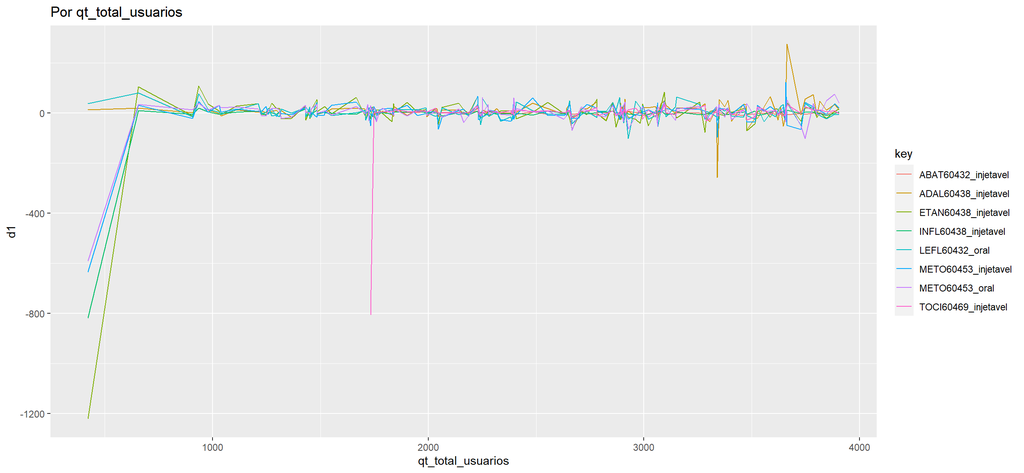

```r
meds %>%
  ggplot(aes(x = qt_total_usuarios, y = d1, colour = key)) +
  geom_line() +
  labs(title = "Por qt_total_usuarios")
```

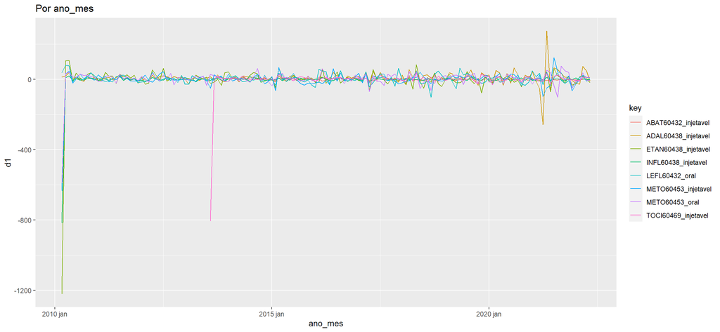

```r
meds %>%
  ggplot(aes(x = ano_mes, y = d1, colour = key)) +
  geom_line() +
  labs(title = "Por ano_mes")
```

Finalmente, as séries diferenciadas parecem todas razoavelmente estacionárias na média com o aumento no número total de pacientes, bem como com o passar do tempo (altamente correlacionado com o número de pacientes total), salvo algumas observações incomuns.

## Seguindo com a modelagem dos medicamentos

```r
for(i in unique(meds$key)) {
  print((meds %>%
     filter(key == i) %>%
     as_tibble() %>%
     select(qt_usuarios))$qt_usuarios %>%
    ggcpgram() +
    labs(title = paste("Periodograma acumulado", i)))
}
```

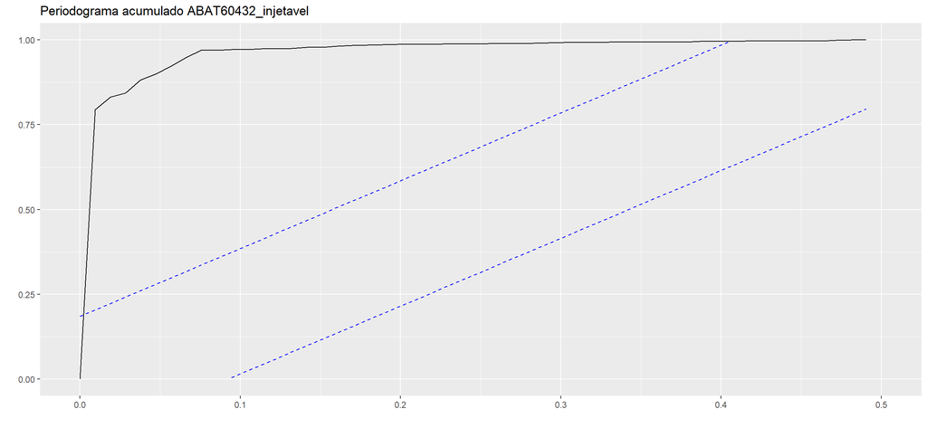

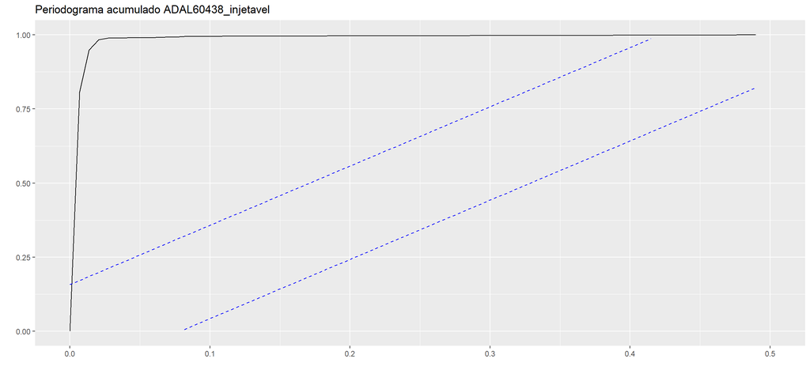

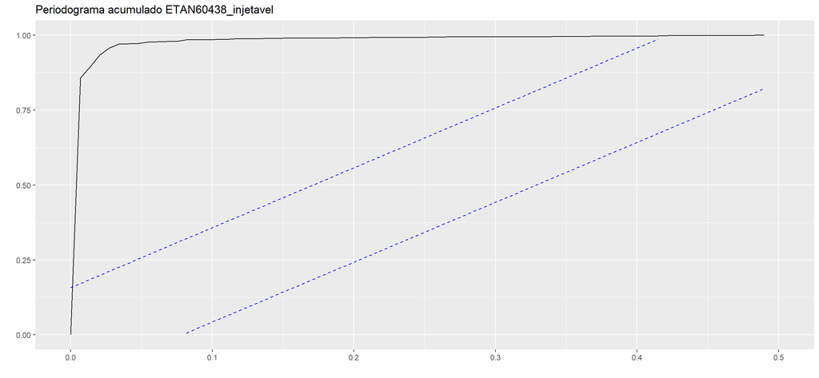

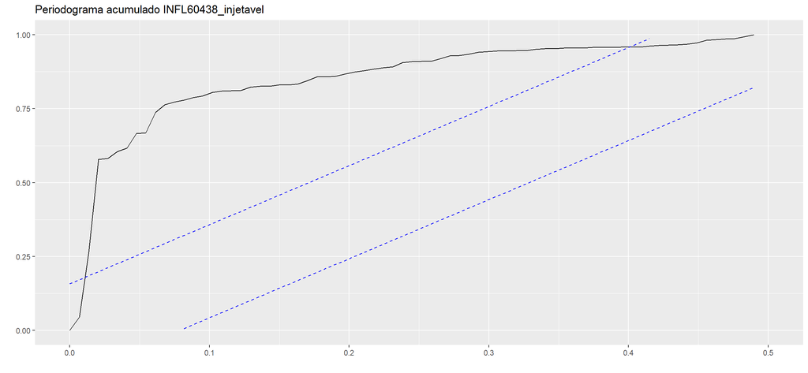

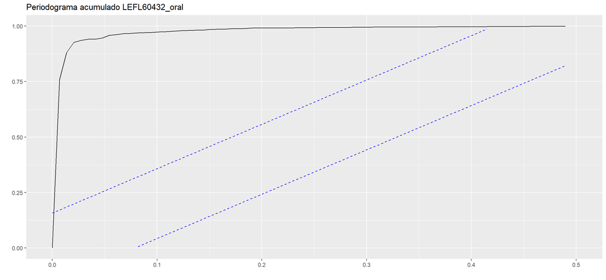

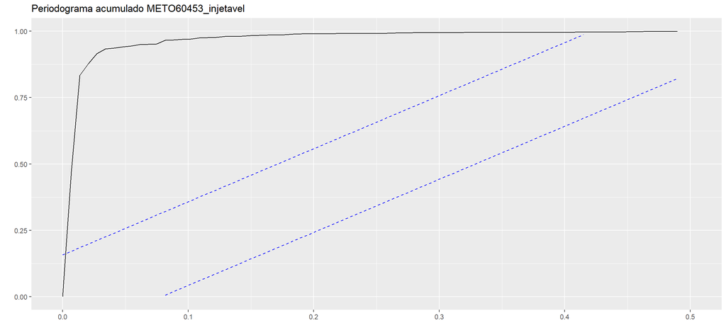

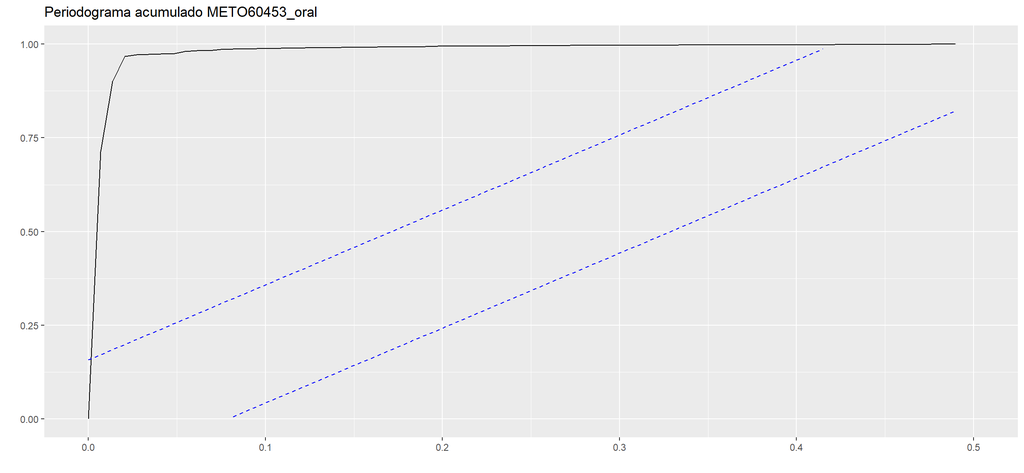

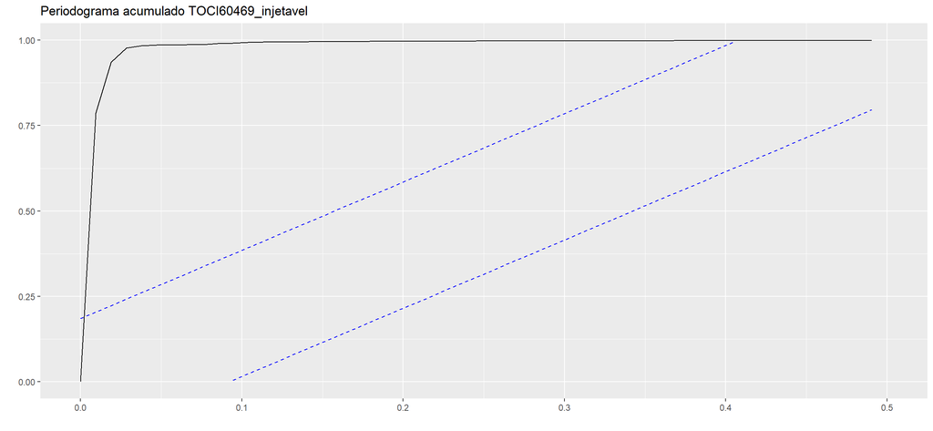

Os periodogramas acumulados de pacientes de todos os medicamentos aponta para a existência de componente sistemático a ser modelado. Sendo assim, a modelagem segue.

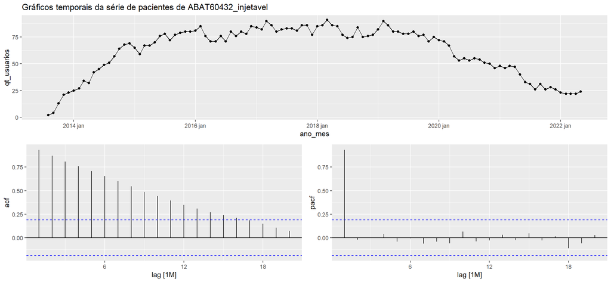

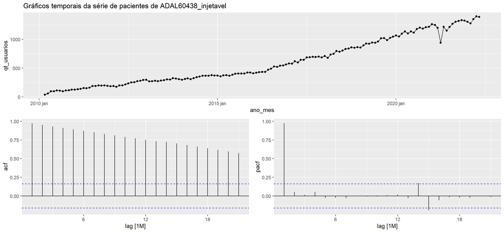

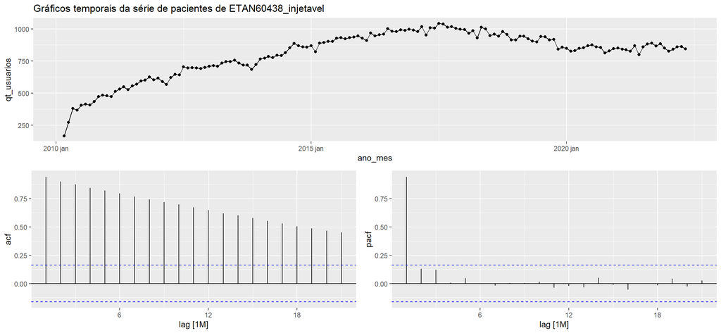

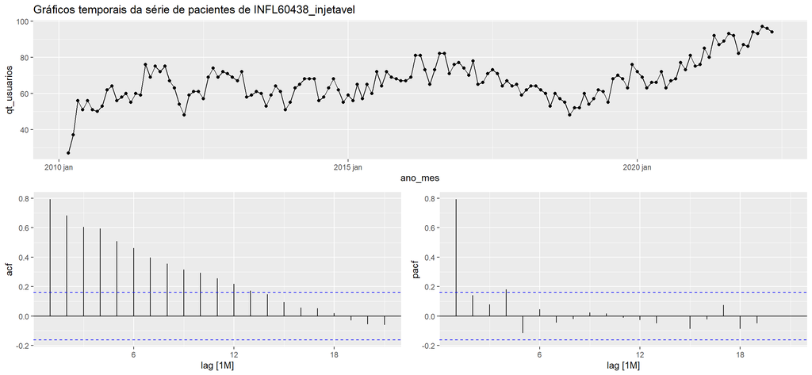

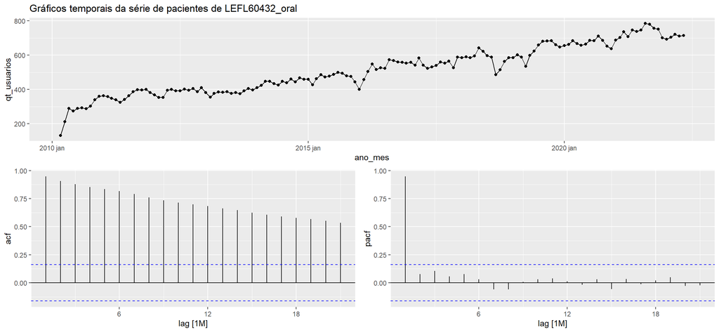

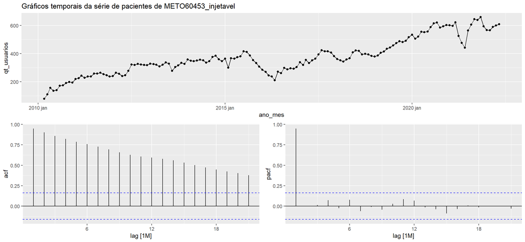

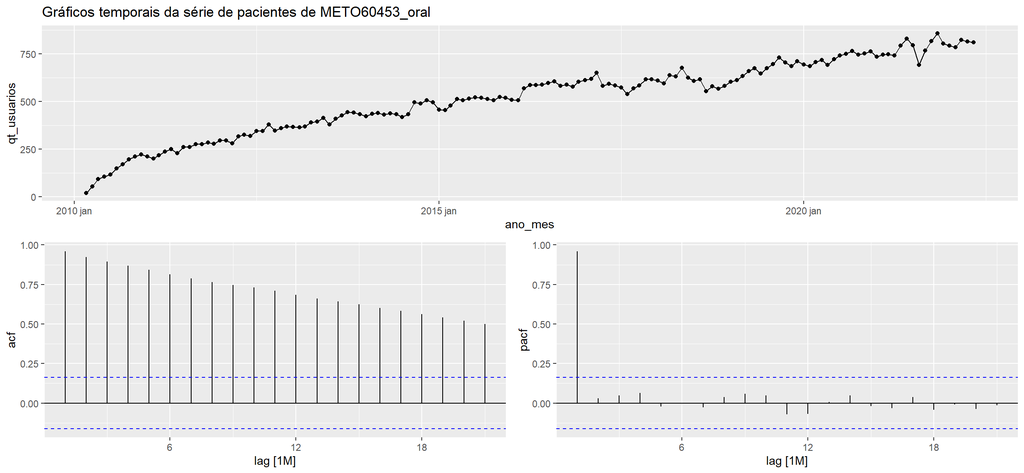

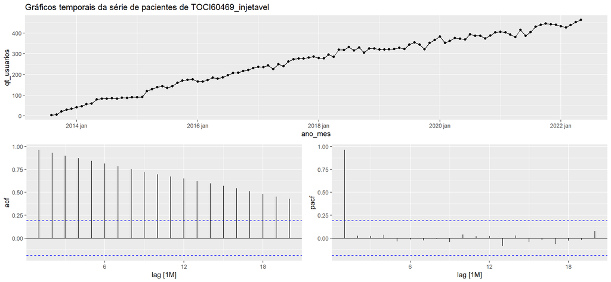

```r
for(i in unique(meds$key)) {
  print(
    meds %>%
      filter(key == i) %>%
      gg_tsdisplay(qt_usuarios, plot_type = "partial") +
      labs(title = paste("Gráficos temporais da série de pacientes de", i))
  )
}
```

A análise dos gráficos de autocorrelação (ACF) e autocorrelação parcial (PACF) sugerem que todas as séries de medicamentos sigam processos AR(1): ACF decrescente infinito e PACF com pico em lag 1 e zero dali em diante. Dessa forma, propõe-se o uso do ARIMA(1,1,0) com drift como modelo A. Além disso, serão ajustados: ARIMA com seleção automática stepwise; LM com erros ARIMA; decomposição em trend + remainder, sendo o trend modelado com ARIMA e o remainder NAIVE; método de alisamento exponencial linear de Holt; alisamento exponencial com erros multiplicativos; LM com componentes de séries temporais.

```r
meds.treino <- meds %>% filter(ano_mes < yearmonth("2020/06")) %>% select(-d1)

meds.models <- meds.treino %>%
  model(
    A = ARIMA(qt_usuarios ~ 1 + pdq(1, 1, 0) + PDQ(0, 0, 0)),
    B = ARIMA(qt_usuarios),
    C = ARIMA(qt_usuarios ~ qt_concorrentes + qt_total_usuarios + pdq()),
    D = decomposition_model(
      STL(qt_usuarios ~ trend()),
      ARIMA(trend ~ qt_concorrentes + qt_total_usuarios),
      NAIVE(remainder)
    ),
    E = ETS(qt_usuarios ~ error("A") + trend("A") + season("N")),
    F = ETS(qt_usuarios ~ error("M") + trend("A") + season("N")),
    G = TSLM(qt_usuarios)
  )
meds.models %>%
  select(key, B:D)
```

```
## # A mable: 8 x 4
## # Key:     key [8]
##   key                                              B                           C
##   <chr>                                      <model>                     <model>
## 1 ABAT60432_inje…                     <ARIMA(0,2,2)>                <NULL model>
## 2 ADAL60438_inje…          <ARIMA(0,2,2)(1,0,1)[12]> <LM w/ ARIMA(0,2,2) errors>
## 3 ETAN60438_inje…          <ARIMA(1,2,2)(1,0,0)[12]> <LM w/ ARIMA(1,2,2) errors>
## 4 INFL60438_inje…             <ARIMA(1,0,4) w/ mean> <LM w/ ARIMA(2,0,1) errors>
## 5 LEFL60432_oral             <ARIMA(0,1,0) w/ drift>                <NULL model>
## 6 METO60453_inje…            <ARIMA(0,1,0) w/ drift>                <NULL model>
## 7 METO60453_oral             <ARIMA(0,1,1) w/ drift>                <NULL model>
## 8 TOCI60469_inje… <ARIMA(1,1,1)(0,0,1)[12] w/ drift>                <NULL model>
## # ℹ 1 more variable: D <model>
```

Não foi possível ajustar o modelo C para os medicamentos cujo número de concorrentes não se alterou durante a série temporal. Desta forma, somente adalimumabe, etanercepte e infliximabe contam com um modelo C ajustado. O mesmo é verificado para o modelo D, pelo mesmo motivo. Como o número de concorrente é constante para estas séries, não há ajuste que possa ser realizado.

```r
mm.t.acc <- meds.models %>%
  accuracy(list(REQM = RMSE), level = 95) %>%
  mutate(periodo = 0, winkler = NaN) %>%
  select(-.type) %>%
  relocate(key, .model, periodo, REQM)
```

```r
# meds.models forecast accuracy 12 e 24

newdata <- meds %>% filter(ano_mes > max(meds.treino$ano_mes), ano_mes <= max(meds.treino$ano_mes) + 12)

meds.cast.12 <- meds.models %>%
  forecast(new_data = newdata)

mm.f.acc.12 <- meds.cast.12 %>%
  accuracy(meds,
           list(REQM = RMSE,
                winkler = winkler_score), level = 95) %>%
  mutate(periodo = 12) %>%
  select(-.type) %>%
  relocate(key, .model, periodo, REQM, winkler) %>%
  arrange(key, .model)

# 24
newdata <- meds %>% filter(ano_mes > max(meds.treino$ano_mes), ano_mes <= max(meds.treino$ano_mes) + 24)

meds.cast.24 <- meds.models %>%
  forecast(new_data = newdata)

mm.f.acc.24 <- meds.cast.24 %>%
  accuracy(meds,
           list(REQM = RMSE,
                winkler = winkler_score), level = 95) %>%
  mutate(periodo = 24) %>%
  select(-.type) %>%
  relocate(key, .model, periodo, REQM, winkler) %>%
  arrange(key, .model)

(mm.f.acc <- mm.t.acc %>%
  union(mm.f.acc.12) %>%
  union(mm.f.acc.24) %>%
  filter(!is.na(REQM)) %>%
  arrange(key, .model) %>%
  pivot_longer(cols = c(REQM, winkler), names_to = "metrica") %>%
  pivot_wider(names_from = periodo,
              values_from = value,
              names_prefix = "v."))
```

```
## # A tibble: 92 × 6
##    key                 .model metrica    v.0  v.12  v.24
##    <chr>               <chr>  <chr>    <dbl> <dbl> <dbl>
##  1 ABAT60432_injetavel A      REQM      4.85  10.1  28.5
##  2 ABAT60432_injetavel A      winkler NaN     45.9  71.0
##  3 ABAT60432_injetavel B      REQM      4.67  11.4  13.6
##  4 ABAT60432_injetavel B      winkler NaN     52.9  94.6
##  5 ABAT60432_injetavel E      REQM      4.67  10.3  11.6
##  6 ABAT60432_injetavel E      winkler NaN     51.2  90.2
##  7 ABAT60432_injetavel F      REQM      4.79  12.3  16.9
##  8 ABAT60432_injetavel F      winkler NaN     40.5  68.1
##  9 ABAT60432_injetavel G      REQM     20.1   20.2  33.7
## 10 ABAT60432_injetavel G      winkler NaN     79.9 153.
## # ℹ 82 more rows
```

A tabela acima apresenta as métricas dos modelos quando avaliados quanto aos seu resíduos em relação à base de treino e aos dados reais para 12 e 24 meses.